# Forecasting in R

# Faceted time plots

In the case of several variables in a time series, it may be helpful to plot them all on a common axis.

We can accomplish that with a tsibble.

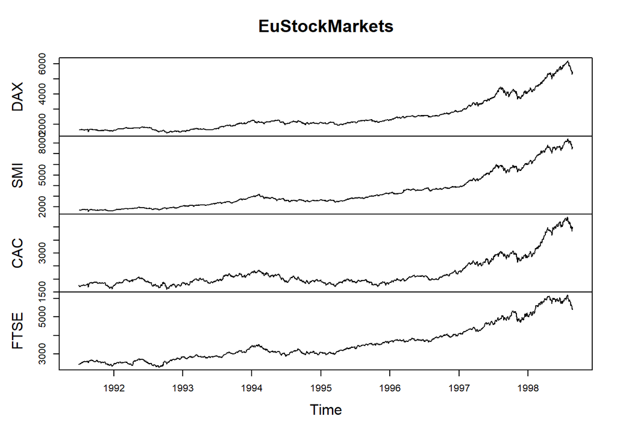

```r
plot(EuStockMarkets) # this works because the data have already been arranged into a ts with multiple variables.
```

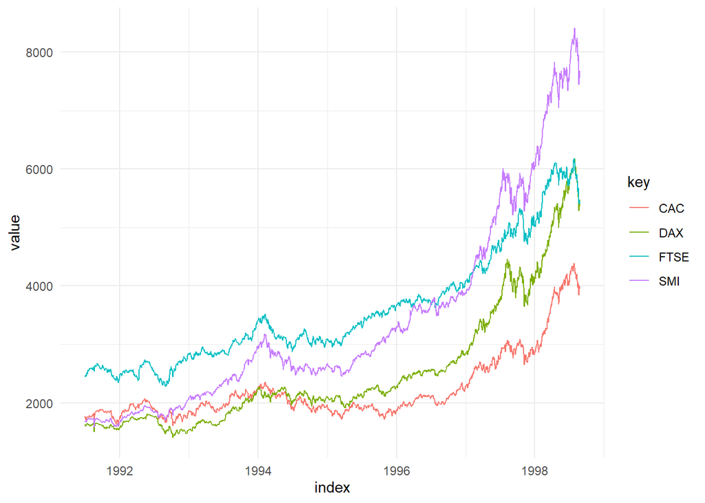

```r
esm_tsb <- as_tsibble(EuStockMarkets)
#autoplot(esm_tsb) + theme_minimal() # this also correctly plots the time series on a single axis.
# this is an equivalent to using a grouping variable on a long data set
ggplot(esm_tsb,aes(x=index,y=value,color=key))+geom_line()+theme_minimal()
```

# Autocorrelation plots

Autocorrelation plots display the relationship between lagged values of a time series. The ACF or autocorrelation function calculates these relationships, and we can display them as a plot along a ‘lag’ axis.

The dashed blue lines indicate autocorrelations that are significantly different from 0.

With seasonal data, you might observe a slight “scalloped” shape that is due to the seasonal component.

"When data have a trend, the autocorrelations for small lags tend to be large and positive because observations nearby in time are also nearby in size. So the ACF of trended time series tend to have positive values that slowly decrease as the lags increase.

When data are seasonal, the autocorrelations will be larger for the seasonal lags (at multiples of the seasonal frequency) than for other lags." [forecasting](https://otexts.com/fpp2/autocorrelation.html)

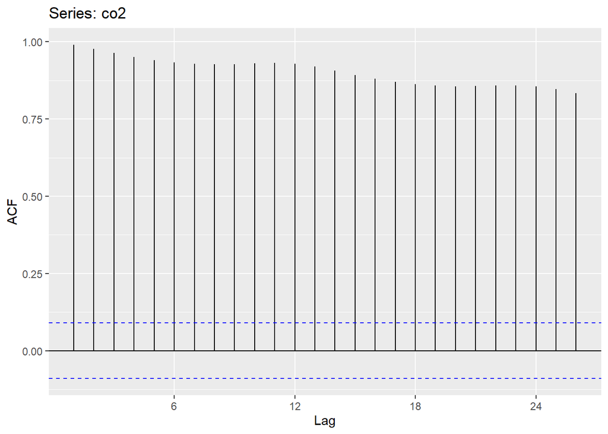

```r
# seasonal autocorrelation - notice a slight scalloped shape in the plot
ggAcf(co2)
```

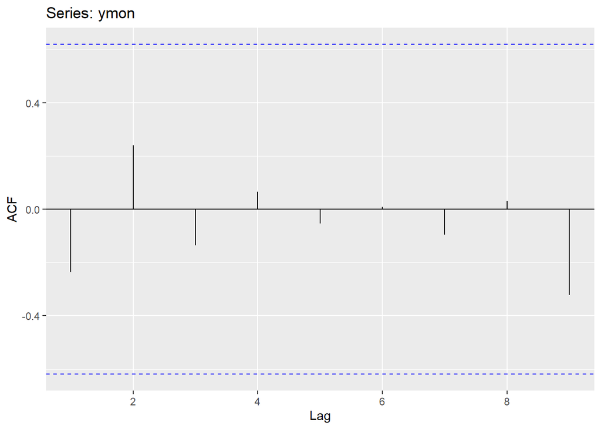

```r
# no autocorrelation
ggAcf(ymon)
```

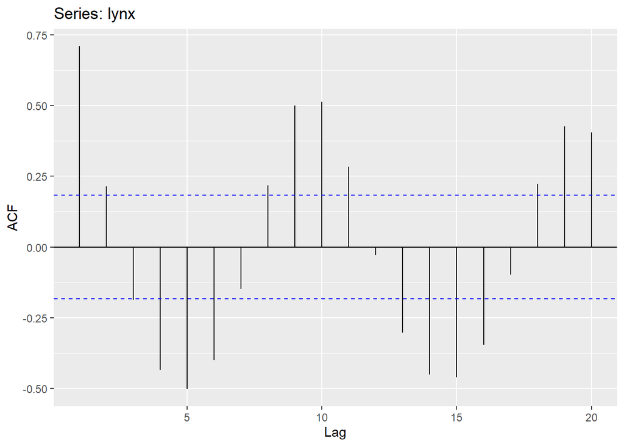

```r
# cyclic but not seasonal autocorrelation in the lynx data.
ggAcf(lynx)
```

# Ex. Visualize your time series

> Make an autoplot and an acf plot of your mpg_ts.

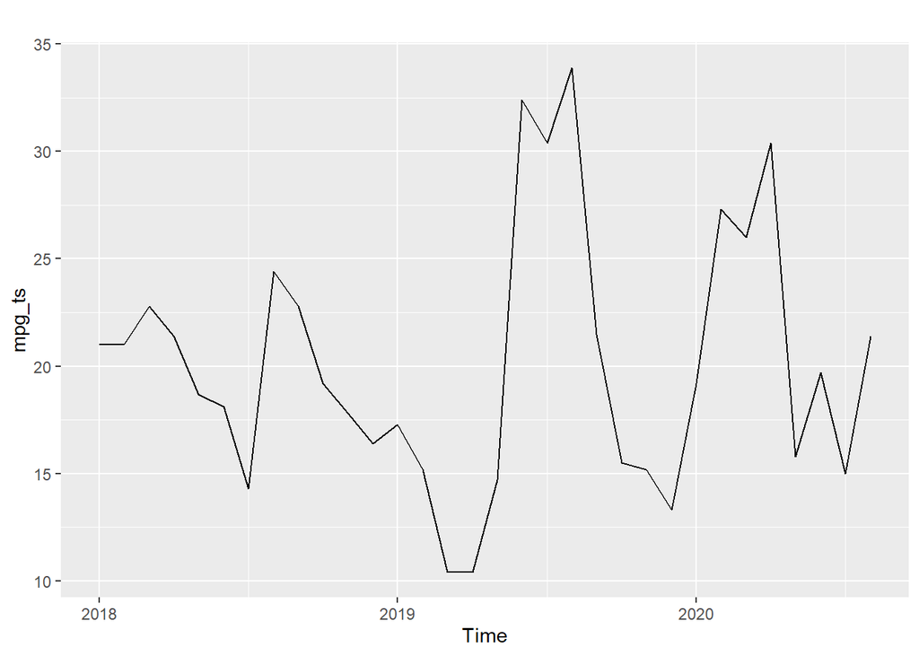

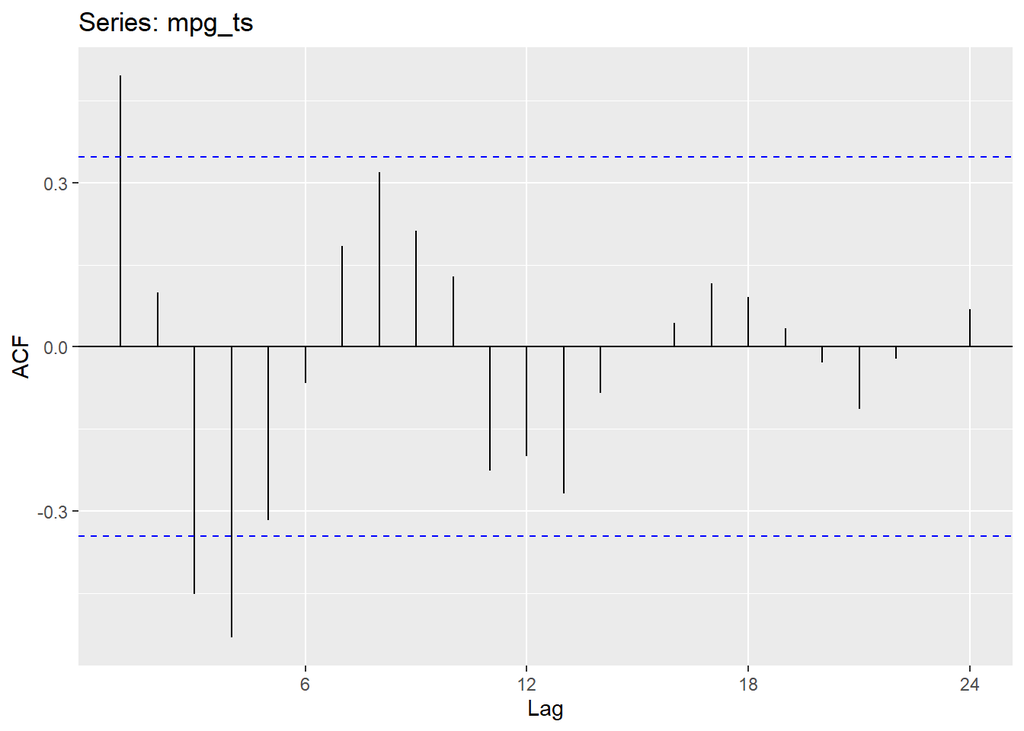

# Simple and naive forecasts

Many simple forecasting methods are surprisingly effective. We summarize them here:

- **average:** forecasts of future values are the mean of historic values
- **naive:** forecasts are set at the last value observed
- **naive-seasonal:** forecast are set at the last seasonal value observed
- **drift:** draw a line from the first to last observations, and extrapolate it

We can create these forecasts with a time series and forecasting functions provided in the forecast package. Here we visualize them, in the next section we’ll demonstrate how to use them.

For each, we specify a **forward horizon** (`h=`)

```r
library(forecast)
avg_forecast <- meanf(co2,h=20) #average forecast
naive_forecast <- naive(co2,h=20) #naive
seasonal_naive <- snaive(co2, h=20) #seasonal naive
# these objects contain the forecast point estimates, as well as prediction intervals
seasonal_naive
```

```
##          Point Forecast    Lo 80    Hi 80    Lo 95    Hi 95
## Jan 1998         363.23 361.4256 365.0344 360.4705 365.9895
## Feb 1998         364.06 362.2556 365.8644 361.3005 366.8195
## Mar 1998         364.61 362.8056 366.4144 361.8505 367.3695
## Apr 1998         366.40 364.5956 368.2044 363.6405 369.1595
## May 1998         366.84 365.0356 368.6444 364.0805 369.5995
## Jun 1998         365.68 363.8756 367.4844 362.9205 368.4395
## Jul 1998         364.52 362.7156 366.3244 361.7605 367.2795
## Aug 1998         362.57 360.7656 364.3744 359.8105 365.3295
## Sep 1998         360.24 358.4356 362.0444 357.4805 362.9995
## Oct 1998         360.83 359.0256 362.6344 358.0705 363.5895
## Nov 1998         362.49 360.6856 364.2944 359.7305 365.2495
## Dec 1998         364.34 362.5356 366.1444 361.5805 367.0995
## Jan 1999         363.23 360.6783 365.7817 359.3274 367.1326
## Feb 1999         364.06 361.5083 366.6117 360.1574 367.9626
## Mar 1999         364.61 362.0583 367.1617 360.7074 368.5126
## Apr 1999         366.40 363.8483 368.9517 362.4974 370.3026
## May 1999         366.84 364.2883 369.3917 362.9374 370.7426
## Jun 1999         365.68 363.1283 368.2317 361.7774 369.5826
## Jul 1999         364.52 361.9683 367.0717 360.6174 368.4226
## Aug 1999         362.57 360.0183 365.1217 358.6674 366.4726
```

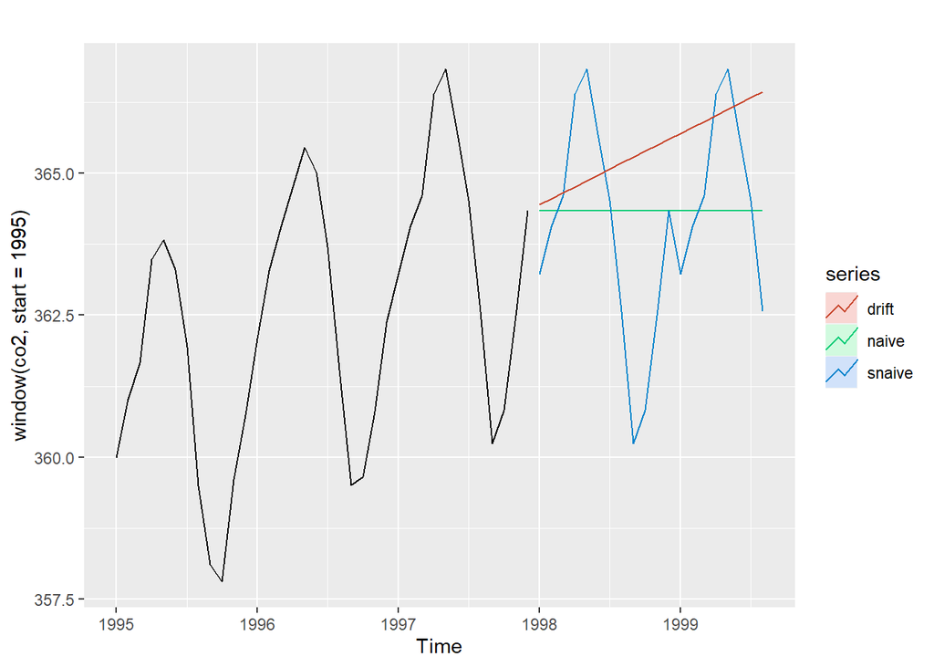

```r
##
drift <- rwf(co2,h=20,drift=TRUE)
autoplot(window(co2,start=1995)) + autolayer(naive_forecast,series="naive",PI=F) +
  autolayer(seasonal_naive,series="snaive",PI=F) + autolayer(drift,series="drift",PI=F)
```

# Create simple and naive forecasts

To create these forecasts, we can use functions from the `forecast` package.

These functions give us point forecasts, as well as 80% and 95% prediction intervals.

**`meanf(ts, h=10)`** average forecast, h is number of periods (horizon) to forecast  
**`naive(ts, h=10)`** naive forecast  
**`snaive(ts, h=10)`** seasonal naive forecast  
**`rwf(ts, h=10, drift=TRUE)`** drift forecast (random walk with drift)

> Ex. Try using these functions on your `mpg_ts` object with 3 periods to forecast.

```
##          Point Forecast    Lo 80    Hi 80    Lo 95    Hi 95
## Sep 2020       20.09062 12.07619 28.10506 7.607998 32.57325
## Oct 2020       20.09062 12.07619 28.10506 7.607998 32.57325
## Nov 2020       20.09062 12.07619 28.10506 7.607998 32.57325
```

```
##          Point Forecast     Lo 80    Hi 80     Lo 95    Hi 95
## Sep 2020           21.4 13.657887 29.14211 9.5594605 33.24054
## Oct 2020           21.4 10.450999 32.34900 4.6549484 38.14505
## Nov 2020           21.4  7.990267 34.80973 0.8915839 41.90842
```

```
##          Point Forecast    Lo 80    Hi 80      Lo 95    Hi 95
## Sep 2020           21.5 7.837554 35.16245  0.6050925 42.39491
## Oct 2020           15.5 1.837554 29.16245 -5.3949075 36.39491
## Nov 2020           15.2 1.537554 28.86245 -5.6949075 36.09491
```

```
##          Point Forecast     Lo 80    Hi 80       Lo 95    Hi 95
## Sep 2020       21.41290 13.542831 29.28298  9.37666647 33.44914
## Oct 2020       21.42581 10.117753 32.73386  4.13163096 38.71998
## Nov 2020       21.43871  7.374496 35.50292 -0.07064951 42.94807
```

# Residuals

We can extract residuals from forecasts using the `residuals` function. Residuals are the **errors,** or the difference between the *observations* and *fitted values* of the forecast. These are only available for methods that are not true forecasts into the unobserved future.

From *Forecasting:* "Residuals are useful in checking whether a model has adequately captured the information in the data. A good forecasting method will yield residuals with the following properties:

1. The residuals are uncorrelated. If there are correlations between residuals, then there is information left in the residuals which should be used in computing forecasts.
2. The residuals have zero mean. If the residuals have a mean other than zero, then the forecasts are biased.

**`residuals(forecast)`** gives the residuals or errors from a forecast

```r
snaive_co2 <- snaive(co2, h=20)
tail(co2)
```

```
##         Jul    Aug    Sep    Oct    Nov    Dec
## 1997 364.52 362.57 360.24 360.83 362.49 364.34
```

```r
resd <- residuals(snaive_co2)
tail(resd)
```

```
##       Jul  Aug  Sep  Oct  Nov  Dec
## 1997 0.82 1.03 0.73 1.18 1.69 1.96
```

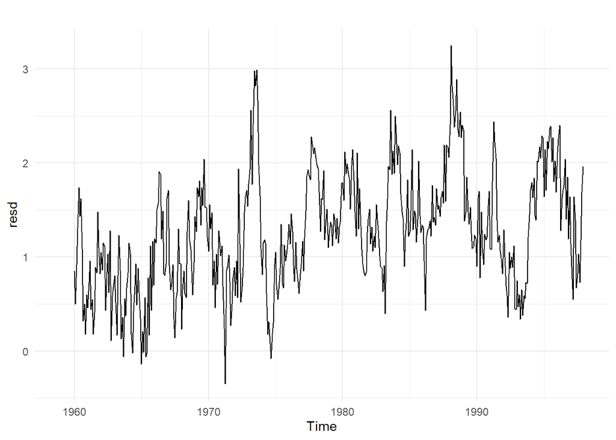

```r
autoplot(resd)+theme_minimal()
```

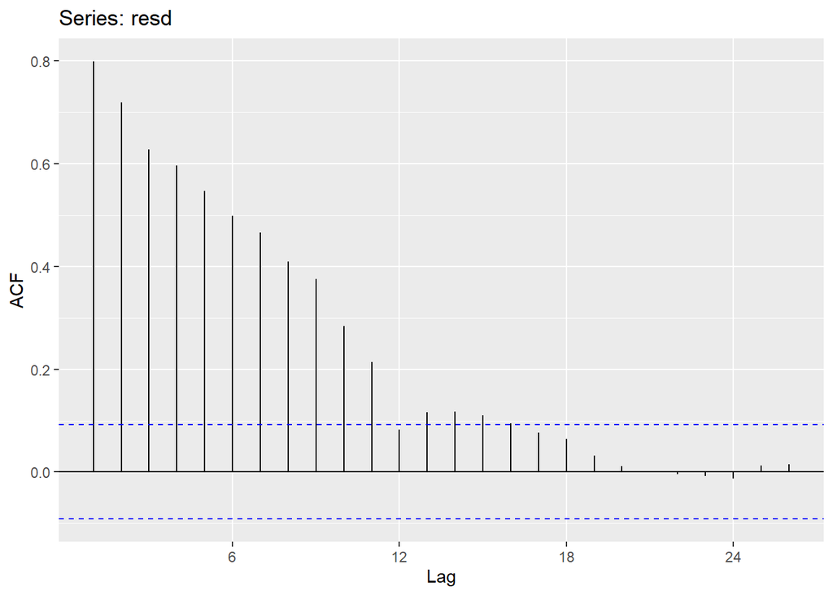

```r
ggAcf(resd) # there is still correlaiton in the residuals
```

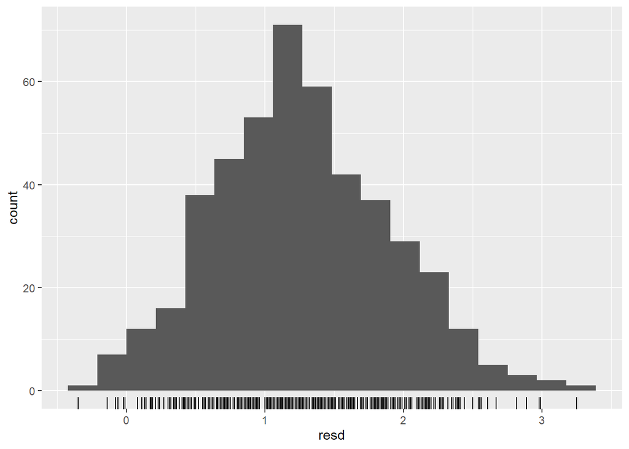

```r
gghistogram(resd) # these don't have a zero mean
```

# Examine your residuals

Choose one of your simple forecasting methods with a period of 3, extract the residuals from the forecast, and examine them.

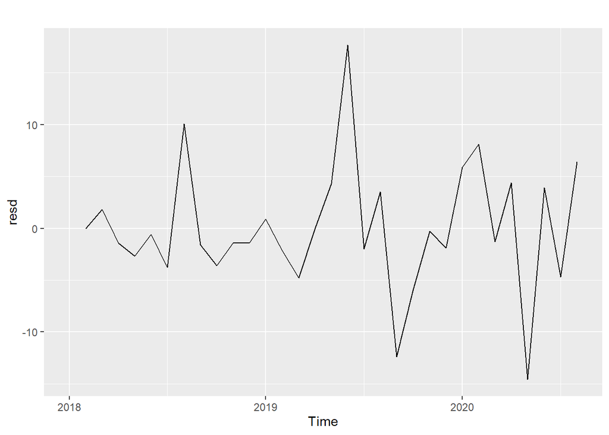

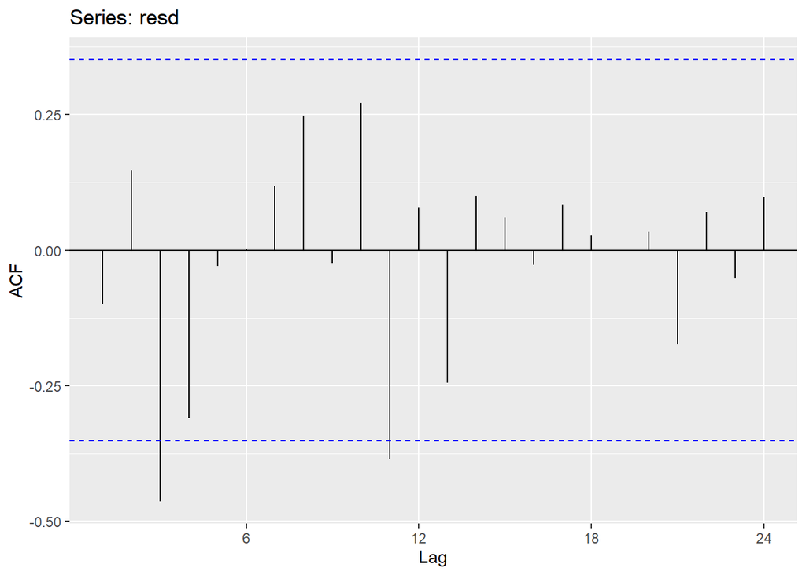

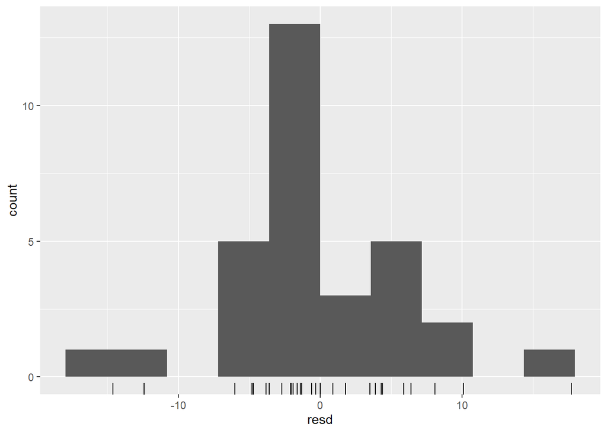

# Subsetting time series

We can extract pieces of a time series with functions like `head,` `tail,` `window,` and `subset.`

**`window(ts, start=2000)`** extracts data from 2000 onwards  
**`subset(ts, quarter=1)`** extracts all q1s from the time series  
**`tail(ts, 5)`** or **last`(xts,5)`**the last 5 observations **`first(xts, 5)`** the first 5 observations **`filter_index(tsibble, start ~ end )`** subset a tsibble

```r
first(mpg_ts,10)
```

```
##  [1] 21.0 21.0 22.8 21.4 18.7 18.1 14.3 24.4 22.8 19.2
```

```r
window(mpg_ts,start=2019)
```

```
##       Jan  Feb  Mar  Apr  May  Jun  Jul  Aug  Sep  Oct  Nov  Dec
## 2019 17.3 15.2 10.4 10.4 14.7 32.4 30.4 33.9 21.5 15.5 15.2 13.3
## 2020 19.2 27.3 26.0 30.4 15.8 19.7 15.0 21.4
```

```r
subset(mpg_ts,month="Mar") #just the March observations
```

```
## Time Series:
## Start = 2018.167
## End = 2020.167
## Frequency = 1
## [1] 22.8 10.4 26.0
```

```r
tail(mpg_ts,3)
```

```
##       Jun  Jul  Aug
## 2020 19.7 15.0 21.4
```

# Decomposition

The `decompose` and `stl` functions can separate a time series into its trend, seasonal, and irregular components.

**`decompose(ts,type="additive)`** additive or multiplicative decomposition **`stl(ts,s.window="periodic")`** additive or multiplicative decomposition

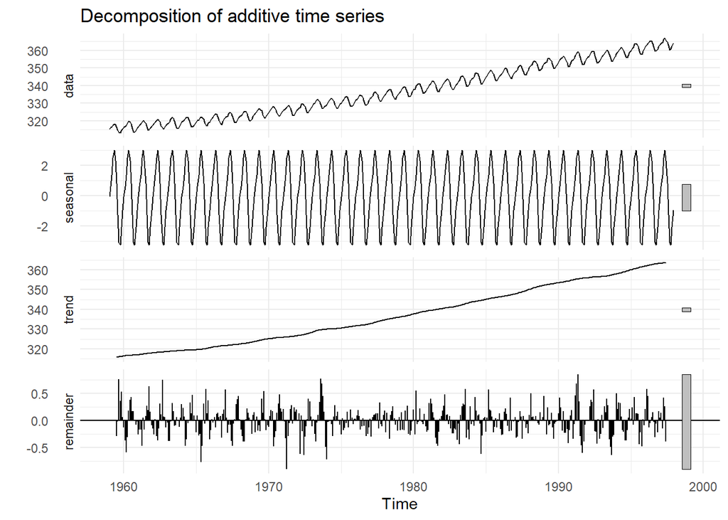

```r
# use decompose function
decompose(co2) %>%
  autoplot() +
  theme_minimal()
```

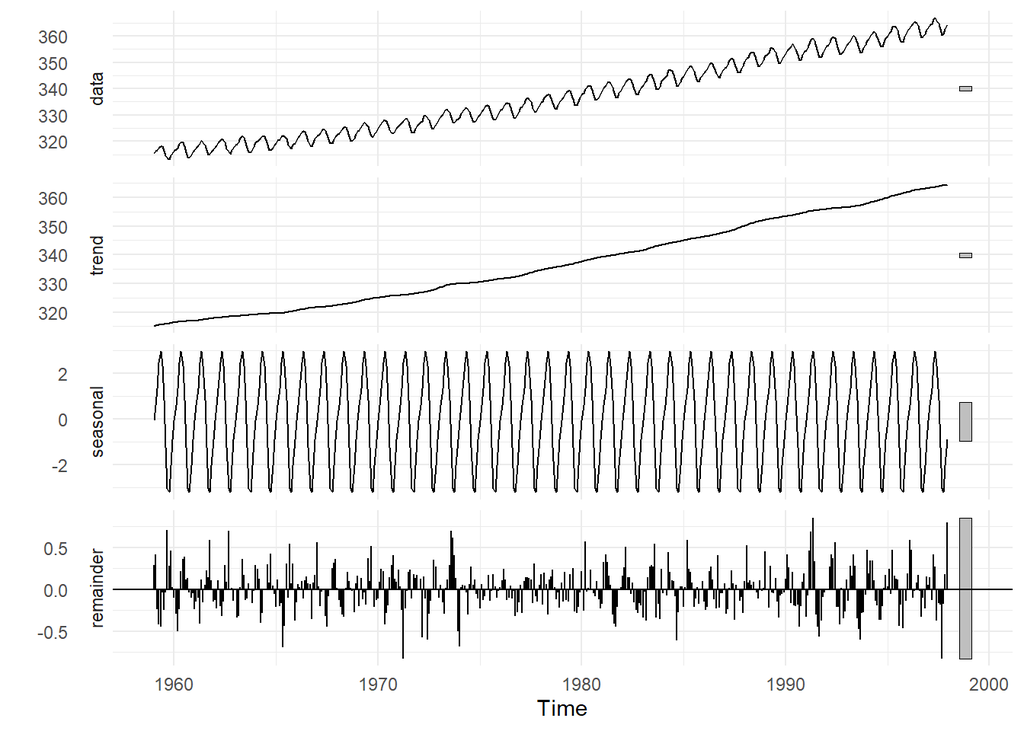

```r
# use stl function
stl(co2,s.window='periodic') %>%
  autoplot() +
  theme_minimal()
```

# Moving average

We can smooth out a time series with a moving average, where we slide a window along a time series index and take averages within the window.

For a tsibble, we’ll use a sliding function to calculate the moving average.

**`ma(ts,order=5)`** calculate a moving average of a time series **`slide_dbl(ncount, mean, na.rm = TRUE, .size = 12)`** slide function from tsibble

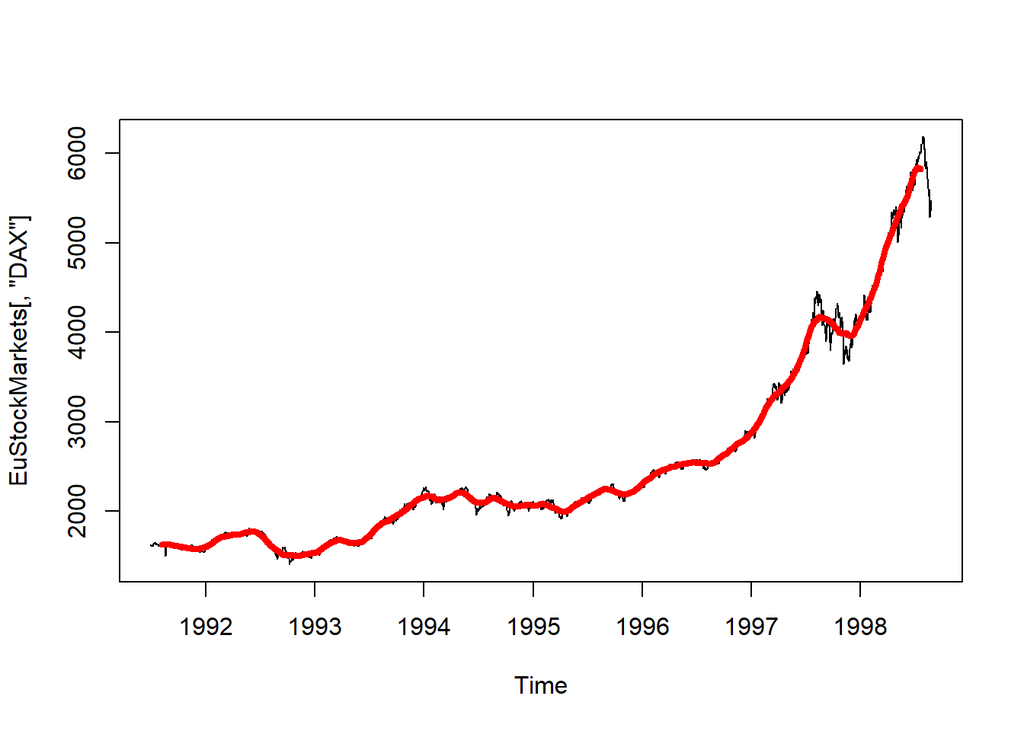

```r
plot(EuStockMarkets[,"DAX"])
lines(ma(EuStockMarkets[,"DAX"],order=50),col="red",lwd=4)
```

```r
head(ma(EuStockMarkets[,"DAX"],order=50),50) # the first 25 are NA because of the window
```

```
## Time Series:
## Start = c(1991, 130)
## End = c(1991, 179)
## Frequency = 260
##  [1]       NA       NA       NA       NA       NA       NA       NA       NA       NA       NA       NA       NA       NA       NA       NA       NA
## [17]       NA       NA       NA       NA       NA       NA       NA       NA       NA 1627.231 1627.451 1627.794 1628.127 1628.394 1628.755 1629.011
## [33] 1628.872 1628.575 1628.170 1627.575 1627.173 1627.026 1626.917 1626.731 1626.390 1625.942 1625.578 1625.382 1625.322 1625.155 1624.645 1623.788
## [49] 1622.751 1621.728
```

```r
#
```

# Ex. Decomposition exercise

> Use the decomposition function to decompose and plot the components of the mpg_ts data, and the EuStockMarkets DAX data.

> To extract just the DAX information from the multiple time series (mts) object, use EuStockMarkets[,"DAX] notation

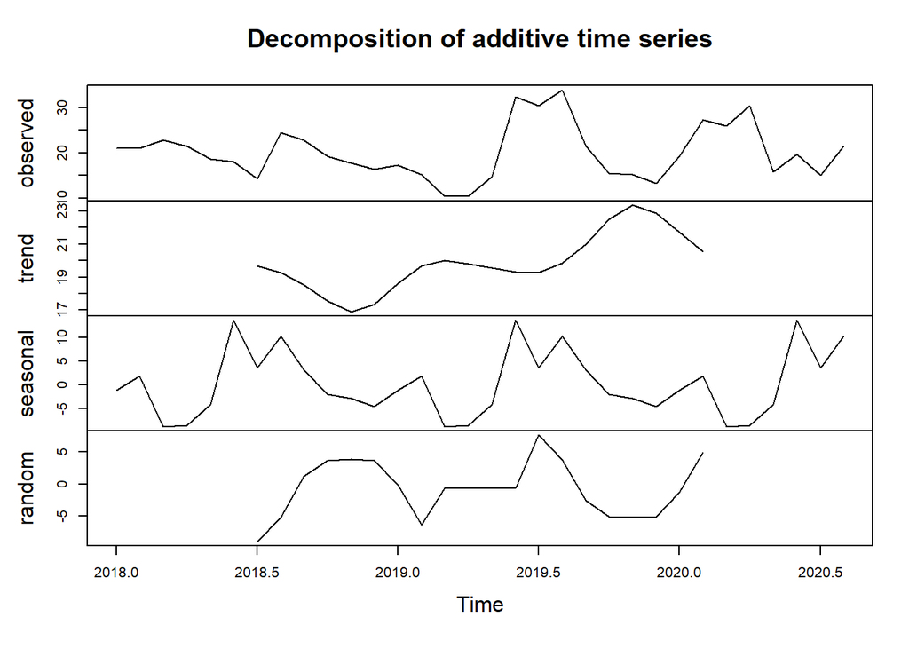

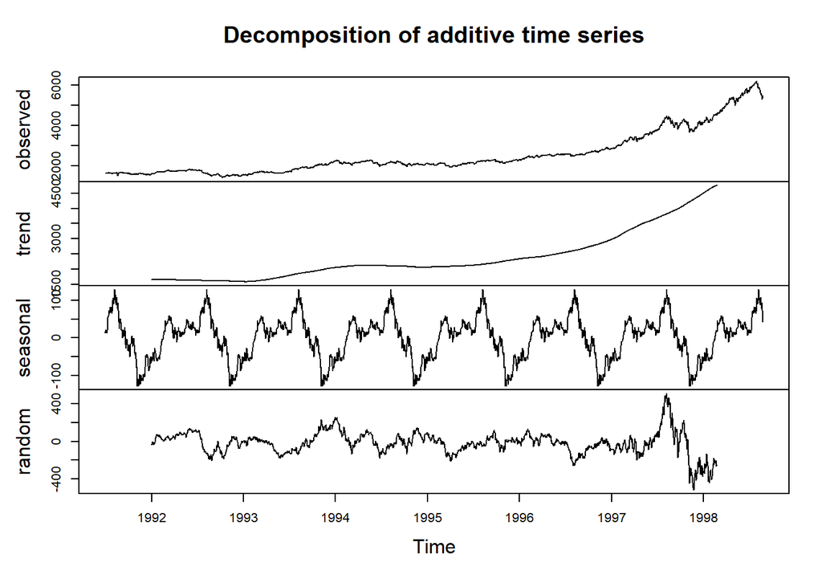